# Pizza Places in NYC

Charles Zhang, Roan Floer-Martinez, Xi Feng, Jinghan Zhou

### **Introduction**

#### Our goal is to help people find the best pizza in New York, depending on their location in the city, price range, and kind of pizzeria they are looking for. To do this, we used three datasets from the TidyTuesday Pizza Party set. We used a dataset from DataFiniti which provides use with geographic data of over 10000 pizza places. We then crossed this against two datasets which included ratings, one by Jared Lander which has ratings from New York locals, and one from the Barstool Sports magazines which covers pizzerias across the nation but only has ratings from Barstool employees.

#### We have already begun doing some analysis and focusing in on New York City. We plan to either continue analyizing the datasets and creating an HTML of our findings, or to create an app to help New Yorkers (and tourists!) find good pizza near them.

[interactive chart not shown]

> Here we didn’t do any analysis, we simply created an interactive map that shows every (non-chain) pizza place in the US.

### **Most popular pizza places**

#### Then we wondered which cities had the most pizza places. Not surprisingly, New York City were well on top.

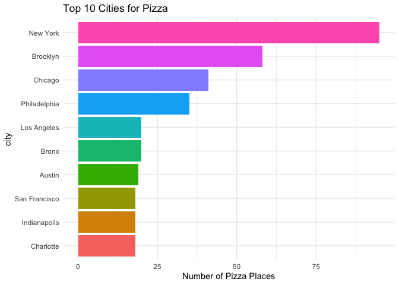

### Best Pizza Places in New York

#### Our data came with ratings for various pizza places. We wanted to find the best pizza places in New York based off this. However, we didn’t just want to calculate the average rating because we think an extreme rating can be more telling. As a result, we calculated the proportion of all ratings among the overall reviews and sorted by the highest proportion of reviews rating the pizzerias as “excellent”. Of those ten, only Little Italy Pizza had reviewers who said they would never go back and four had no “poor” ratings either. Patsy’s pizza (which I used to order as a kid!) was the winner with 2/3rds of reviewers calling its pizza “excellent”.

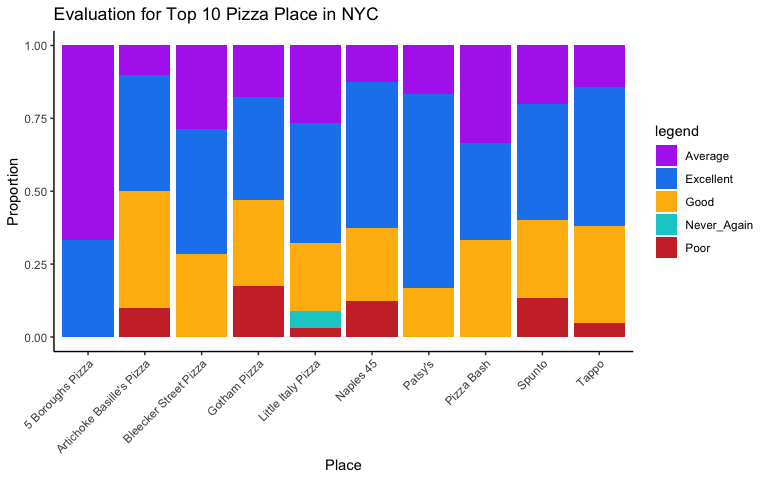

### **Further Study**

#### Next, we would like to analyze the review scores for pizza places in the data set from the Barstool Sports magazines

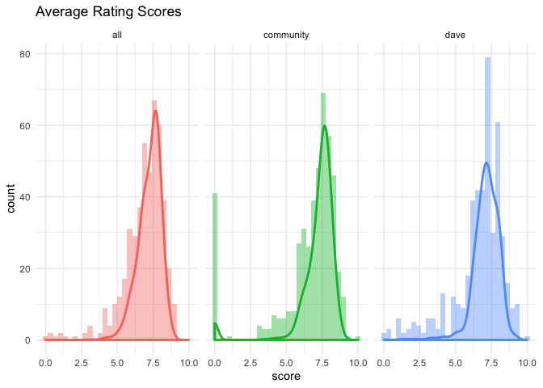

> Overall, the average scores distributions of all reviews, the community rating, and the Dave rating are similar but still exist differences. So our group will determine to use which score, or which combinations of socres for further analysis.

#### Incidentally, we compared the average review socres among NYC, Brooklyn, Boston, and Minneapolis.

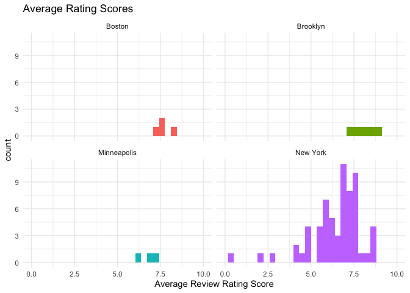

> This plot implies that we have more significant distrubution for the average rating socre in New York. This is also the reason why we choose to use pizzeria in NYC